## In-class worksheet 7

**Feb 9, 2016**

In this worksheet, we will use the libraries ggplot2, dplyr, and nycflights13:

```r
library(ggplot2)
theme_set(theme_bw(base_size=12)) # set default ggplot2 theme
library(dplyr)
library(nycflights13)
```

The nycflights13 package contains information about all planes departing fron New York City in 2013.

## 1. Joining tables

The following two tables list the population size and area (in sq miles) of three major Texas cities each:

```r
population <- read.csv(text=
"city,year,population
Houston,2014,2239558
San Antonio,2014,1436697
Austin,2014,912791
Austin,2010,790390", stringsAsFactors = FALSE)
population
```

```
##          city year population
## 1     Houston 2014    2239558
## 2 San Antonio 2014    1436697
## 3      Austin 2014     912791
## 4      Austin 2010     790390
```

```r
area <- read.csv(text=
"city,area
Houston,607.5
Dallas,385.6
Austin,307.2", stringsAsFactors = FALSE)
area
```

```
##      city  area
## 1 Houston 607.5
## 2  Dallas 385.6
## 3  Austin 307.2
```

Combine these two tables using the functions `left_join()`, `right_join()`, and `inner_join()`. How do these join functions differ in their results?

```r
left_join(population, area)
```

```
##          city year population  area
## 1     Houston 2014    2239558 607.5
## 2 San Antonio 2014    1436697    NA
## 3      Austin 2014     912791 307.2
## 4      Austin 2010     790390 307.2
```

The function `left_join()` keeps the left table as is and fills in data from the right table where available. Missing values are listed as `NA`.

```r
inner_join(population, area)
```

```
##      city year population  area
## 1 Houston 2014    2239558 607.5
## 2  Austin 2014     912791 307.2
## 3  Austin 2010     790390 307.2
```

The function `inner_join()` only keeps the rows for which there is data in both tables.

```r
right_join(population, area)
```

```
##      city year population  area
## 1 Houston 2014    2239558 607.5
## 2  Dallas   NA         NA 385.6
## 3  Austin 2014     912791 307.2
## 4  Austin 2010     790390 307.2
```

The functioin `right_join()` keeps the right table as is and fills in data form the left table where available. It is equivalent to `left_join()` with the arguments listed in the opposite order:

```r
left_join(area, population)
```

```
##      city  area year population
## 1 Houston 607.5 2014    2239558
## 2  Dallas 385.6   NA         NA
## 3  Austin 307.2 2014     912791
## 4  Austin 307.2 2010     790390
```

## 2. Relationship between arrival delay and age of plane

The table `flights` from nycflights13 contains information about individual departures:

```r
flights
```

```
## Source: local data frame [336,776 x 16]
##
##    year month day dep_time dep_delay arr_time arr_delay carrier tailnum
## 1  2013     1   1      517         2      830        11      UA  N14228
## 2  2013     1   1      533         4      850        20      UA  N24211
## 3  2013     1   1      542         2      923        33      AA  N619AA
## 4  2013     1   1      544        -1     1004       -18      B6  N804JB
## 5  2013     1   1      554        -6      812       -25      DL  N668DN
## 6  2013     1   1      554        -4      740        12      UA  N39463
## 7  2013     1   1      555        -5      913        19      B6  N516JB
## 8  2013     1   1      557        -3      709       -14      EV  N829AS
## 9  2013     1   1      557        -3      838        -8      B6  N593JB
## 10 2013     1   1      558        -2      753         8      AA  N3ALAA
## ..  ...   ... ...      ...       ...      ...       ...     ...     ...
## Variables not shown: flight (int), origin (chr), dest (chr), air_time
##   (dbl), distance (dbl), hour (dbl), minute (dbl)
```

Individual planes are indicated by their tail number (`tailnum` in the table). Calculate the mean arrival delay (`arr_delay`) for each tail number. Do you notice anything unusual in the result? Try to calculate the mean with and without adding the option `na.rm=TRUE`.

```r
# without na.rm=TRUE:
flights %>% group_by(tailnum) %>% summarize(mean_delay=mean(arr_delay))
```

```
## Source: local data frame [4,044 x 2]
##
##    tailnum mean_delay
## 1                  NA
## 2   D942DN 31.5000000
## 3   N0EGMQ         NA
## 4   N10156         NA
## 5   N102UW  2.9375000
## 6   N103US -6.9347826
## 7   N104UW         NA
## 8   N10575         NA
## 9   N105UW -0.2666667
## 10  N107US -5.7317073
## ..     ...        ...
```

```r
# with na.rm=TRUE:
flights %>% group_by(tailnum) %>% summarize(mean_delay=mean(arr_delay, na.rm=TRUE))
```

```
## Source: local data frame [4,044 x 2]
##
##    tailnum mean_delay
## 1                 NaN
## 2   D942DN 31.5000000
## 3   N0EGMQ  9.9829545
## 4   N10156 12.7172414
## 5   N102UW  2.9375000
## 6   N103US -6.9347826
## 7   N104UW  1.8043478
## 8   N10575 20.6914498
## 9   N105UW -0.2666667
## 10  N107US -5.7317073
## ..     ...        ...
```

The option `na.rm=TRUE` removes missing values before averaging. Without this option, many of the averages end up as missing values (`NA`).

Information about individual planes is availabe in the table `planes`:

```r
planes
```

```
## Source: local data frame [3,322 x 9]
##
##    tailnum year                    type     manufacturer     model engines
## 1   N10156 2004 Fixed wing multi engine          EMBRAER EMB-145XR       2
## 2   N102UW 1998 Fixed wing multi engine AIRBUS INDUSTRIE  A320-214       2
## 3   N103US 1999 Fixed wing multi engine AIRBUS INDUSTRIE  A320-214       2
## 4   N104UW 1999 Fixed wing multi engine AIRBUS INDUSTRIE  A320-214       2
## 5   N10575 2002 Fixed wing multi engine          EMBRAER EMB-145LR       2
## 6   N105UW 1999 Fixed wing multi engine AIRBUS INDUSTRIE  A320-214       2
## 7   N107US 1999 Fixed wing multi engine AIRBUS INDUSTRIE  A320-214       2
## 8   N108UW 1999 Fixed wing multi engine AIRBUS INDUSTRIE  A320-214       2
## 9   N109UW 1999 Fixed wing multi engine AIRBUS INDUSTRIE  A320-214       2
## 10  N110UW 1999 Fixed wing multi engine AIRBUS INDUSTRIE  A320-214       2
## ..     ...  ...                     ...              ...       ...     ...
## Variables not shown: seats (int), speed (int), engine (chr)
```

In particular, this table lists the year each individual plane was manufactured. Make a combined table that holds tail number, mean arrival delay, and year of manufacture for each plane. Then plot mean arrival delay vs. year of manufacture.

```r
flights %>% group_by(tailnum) %>%
  summarize(mean_delay=mean(arr_delay, na.rm=TRUE)) %>% # calculate mean delay
  left_join(planes) %>% # combine with planes
  select(tailnum, mean_delay, year) -> delay_year
delay_year
```

```
## Source: local data frame [4,044 x 3]
##
##    tailnum mean_delay year
## 1                 NaN   NA
## 2   D942DN 31.5000000   NA
## 3   N0EGMQ  9.9829545   NA
## 4   N10156 12.7172414 2004
## 5   N102UW  2.9375000 1998
## 6   N103US -6.9347826 1999
## 7   N104UW  1.8043478 1999
## 8   N10575 20.6914498 2002
## 9   N105UW -0.2666667 1999
## 10  N107US -5.7317073 1999
## ..     ...        ...  ...
```

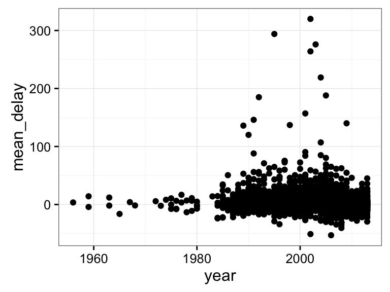

```r
ggplot(delay_year, aes(x=year, y=mean_delay)) + geom_point()
```

## 3. Relationship between arrival delay and temperature

Now calculate the mean arrival delay for each day of the year, and store in a variable called `daily_delays`.

```r
flights %>% group_by(year, month, day) %>% summarize(mean_delay=mean(arr_delay, na.rm=T)) -> daily_delays
daily_delays
```

```
## Source: local data frame [365 x 4]
## Groups: year, month
##
##    year month day mean_delay
## 1  2013     1   1 12.6510229
## 2  2013     1   2 12.6928879
## 3  2013     1   3  5.7333333
## 4  2013     1   4 -1.9328194
## 5  2013     1   5 -1.5258020
## 6  2013     1   6  4.2364294
## 7  2013     1   7 -4.9473118
## 8  2013     1   8 -3.2275785
## 9  2013     1   9 -0.2642777
## 10 2013     1  10 -5.8988159
## ..  ...   ... ...        ...
```

We want to correlate these delay values with the temperature of each day. The data frame `weather` holds temperature measurements for each hour of each day:

```r
weather
```

```
## Source: local data frame [8,719 x 14]
## Groups: month, day, hour
##
##    origin year month day hour  temp  dewp humid wind_dir wind_speed
## 1     EWR 2013     1   1    0 37.04 21.92 53.97      230   10.35702
## 2     EWR 2013     1   1    1 37.04 21.92 53.97      230   13.80936
## 3     EWR 2013     1   1    2 37.94 21.92 52.09      230   12.65858
## 4     EWR 2013     1   1    3 37.94 23.00 54.51      230   13.80936
## 5     EWR 2013     1   1    4 37.94 24.08 57.04      240   14.96014
## 6     EWR 2013     1   1    6 39.02 26.06 59.37      270   10.35702
## 7     EWR 2013     1   1    7 39.02 26.96 61.63      250    8.05546
## 8     EWR 2013     1   1    8 39.02 28.04 64.43      240   11.50780
## 9     EWR 2013     1   1    9 39.92 28.04 62.21      250   12.65858
## 10    EWR 2013     1   1   10 39.02 28.04 64.43      260   12.65858
## ..    ...  ...   ... ...  ...   ...   ...   ...      ...        ...
## Variables not shown: wind_gust (dbl), precip (dbl), pressure (dbl), visib
##   (dbl)
```

First, calculate the mean temperature for each day, and store in a variable called `mean_temp`:

```r
weather %>% group_by(year, month, day) %>% summarize(mean_temp=mean(temp)) -> mean_temp
mean_temp
```

```
## Source: local data frame [365 x 4]
## Groups: year, month
##
##    year month day mean_temp
## 1  2013     1   1   38.4800
## 2  2013     1   2   28.8350
## 3  2013     1   3   29.4575
## 4  2013     1   4   33.4775
## 5  2013     1   5   36.7325
## 6  2013     1   6   37.9700
## 7  2013     1   7   41.2775
## 8  2013     1   8   38.3150
## 9  2013     1   9   40.7825
## 10 2013     1  10   44.1875
## ..  ...   ... ...       ...
```

Now combine the mean delay and the mean temperature into one table, and then plot mean delay vs. mean temperature.

```r
daily_delays %>% left_join(mean_temp) %>% select(year, month, day, mean_delay, mean_temp) -> delay_temp
```

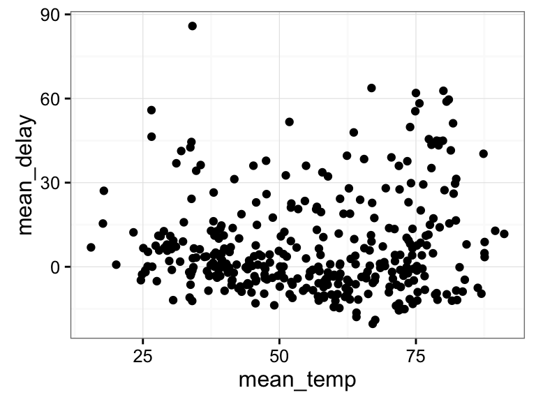

```r
ggplot(delay_temp, aes(x=mean_temp, y=mean_delay)) + geom_point()
```

It looks like there is no strong relationship between daily temperature and mean delay.

## 4. If this was easy

Find out for how many tail numbers in the `flights` data set we have no information in the `planes` data set. What do we have to pay attention to when joining the `flights` and `planes` tables?

```r
flights %>% left_join(planes, by='tailnum') %>% filter(is.na(type)) %>% tally()
```

```
## Source: local data frame [1 x 1]
##
##       n
## 1 52606
```

There are 52606 such flights. It is important here to tell the `left_join()` function to join by `tailnum`, otherwise it tries to join by `tailnum` and `year`, but `year` has different meanings in the two tables.

Calculate the mean arrival delay by plane model and by plane engine. Sort in order of descending mean delay. Remove all tailnumbers for which no plane information is available.

```r
# 1. plane model
# we first join the fligths table and the planes table to make a new table holding plane model, engine, and arrival delay
flights %>% left_join(planes, by='tailnum') %>%
  filter(!is.na(type)) %>%
  select(model, engine, arr_delay) -> delay_table
delay_table
```

```
## Source: local data frame [284,170 x 3]
##
##          model    engine arr_delay
## 1      737-824 Turbo-fan        11
## 2      737-824 Turbo-fan        20
## 3      757-223 Turbo-fan        33
## 4     A320-232 Turbo-fan       -18
## 5      757-232 Turbo-fan       -25
## 6    737-924ER Turbo-fan        12
## 7     A320-232 Turbo-fan        19
## 8  CL-600-2B19 Turbo-fan       -14
## 9     A320-232 Turbo-fan        -8
## 10    A320-232 Turbo-fan        -2
## ..         ...       ...       ...
```

```r
# we next calculate the mean delay per model
delay_table %>% group_by(model) %>%
  summarize(mean_delay=mean(arr_delay, na.rm=T)) %>%
  arrange(desc(mean_delay)) -> model_delay
model_delay
```

```
## Source: local data frame [127 x 2]
##
##       model mean_delay
## 1   747-451  120.00000
## 2   757-351   72.50000
## 3  A330-223   46.50000
## 4      G-IV   41.16667
## 5   777-224   40.75000
## 6  A319-115   33.47312
## 7     A109E   30.64516
## 8  A340-313   29.82353
## 9  MD-90-30   28.47945
## 10  737-76N   28.35610
## ..      ...        ...
```

```r
# 2. plane engine
# we go back to the delay_table we created above, and now calculate the mean per engine
delay_table %>% group_by(engine) %>%
  summarize(mean_delay=mean(arr_delay, na.rm=T)) %>%
  arrange(desc(mean_delay)) -> engine_delay
engine_delay
```

```
## Source: local data frame [6 x 2]
##
##          engine mean_delay
## 1       4 Cycle   9.723404
## 2   Turbo-shaft   9.281796
## 3     Turbo-fan   7.721963
## 4 Reciprocating   5.715208
## 5    Turbo-prop   4.891304
## 6     Turbo-jet   3.192066
```